# Verzani Problem Set

## Problem 10.2

Repeat the above for the data set `smokyph`. This data set measures pH levels for water samples in the Great Smoky Mountains. Use the `waterph` column to test the null hypothesis that $\mu = 7$. What is a reasonable alternative?

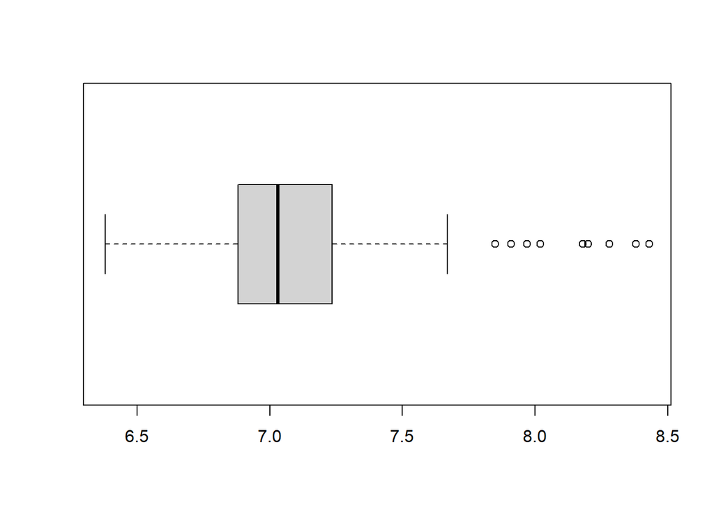

```r
> head(smokyph)
  waterph  elev code
1    7.91 0.244    0
2    7.14 0.375    0
3    6.81 0.567    0
4    6.97 0.512    0
5    7.21 0.408    0
6    6.94 0.512    0
> boxplot(smokyph$waterph, horizontal = TRUE)
```

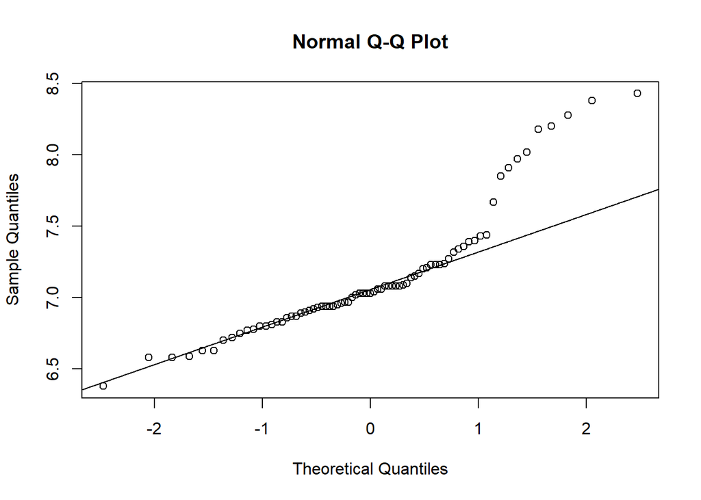

```r
> qqnorm(smokyph$waterph)
> qqline(smokyph$waterph)
```

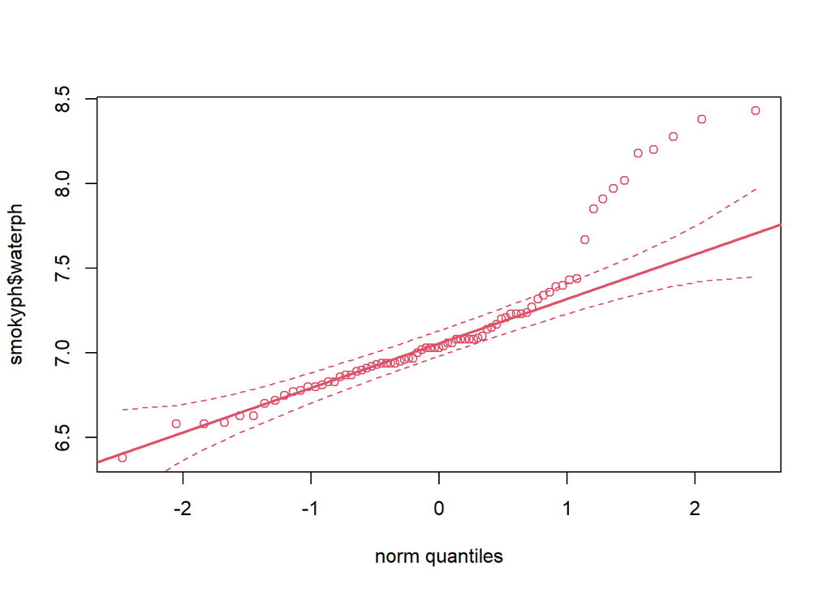

```r
> qqplot.das(smokyph$waterph)
```

$H_0: X$ is normally distributed

$H_A: X$ isn’t normally distributed

```r
> shapiro.test(smokyph$waterph)

    Shapiro-Wilk normality test

data:  smokyph$waterph
W = 0.86654, p-value = 1.178e-06
```

The $p-value = 1.178e-06 < 0.05 = \alpha$, so we reject $H_0$ the data is not normally distributed.

We can make hypothesis test for the median. Let’s see what is the median of the sample.

```r
> median(smokyph$waterph)
[1] 7.03
```

So it is reasonable to test

$$H_0: Me = 7$$
$$H_A: Me \neq 7$$

```r
> wilcox.test(smokyph$waterph,
+        alternative = "two.sided",
+        mu = 7,
+        conf.level = 0.95)

    Wilcoxon signed rank test with continuity correction

data:  smokyph$waterph
V = 1711, p-value = 0.08177
alternative hypothesis: true location is not equal to 7
```

The $p-value = 0.08177 > 0.05 = \alpha$, so we have no reason to reject $H_0$. We can assume with $95\%$ confidence that the $Me = 7$.

## Problem 10.3

An exit poll by a news station of $900$ people in the state of Florida found $440$ voting for Bush and $460$ voting for Gore. Does the data support the hypothesis that Bush received $p = 50\%$ of the state’s vote?

$$H_0: p = 0.5$$
$$H_A: p \neq 0.5$$
We can calculate the critical area

```r
> alpha = 0.05
> qbinom(alpha/2, 900, 1/2)
[1] 421
> qbinom(1-alpha/2, 900, 1/2)
[1] 479
```

$$W_{\alpha} = \{X < 421 \cup X > 479\}$$
$440$ is outside of the critical area, so we have no evidence to reject $H_0$. We expect Bush to receive $0.5$ from the voting.

Or using the $p-value$

```r
> pbinom(440, 900, 1/2) + pbinom(460, 900, 1/2, lower.tail = FALSE)
[1] 0.5052435
```

The $p-value = 0.5052 > 0.05 = \alpha$, so we have no evidence to reject $H_0$. We expect Bush to receive $0.5$ from the voting.

We can use

```r
> binom.test(440, 900, p = 0.5, conf.level = 0.95)

    Exact binomial test

data:  440 and 900
number of successes = 440, number of trials = 900, p-value = 0.5265
alternative hypothesis: true probability of success is not equal to 0.5
95 percent confidence interval:
 0.4557575 0.5220933
sample estimates:
probability of success
             0.4888889
```

or

```r
> prop.test(440, 900, p = 0.5, conf.level = 0.95)

    1-sample proportions test with continuity correction

data:  440 out of 900, null probability 0.5
X-squared = 0.40111, df = 1, p-value = 0.5265
alternative hypothesis: true p is not equal to 0.5
95 percent confidence interval:
 0.4557952 0.5220786
sample estimates:
        p
0.4888889
```

The $p-value = 0.5265 > 0.05 = \alpha$, so we have no evidence to reject $H_0$. We expect Bush to receive $0.5$ from the voting.

## Problem 10.4

Load the data set `cancer`. Look only at `cancer[['stomach']]`. These are survival times for stomach cancer patients taking a large dosage of Vitamin C. Test the null hypothesis that the Median is $100$ days. Should you also use a t-test? Why or why not? (A boxplot of the cancer data is interesting.)

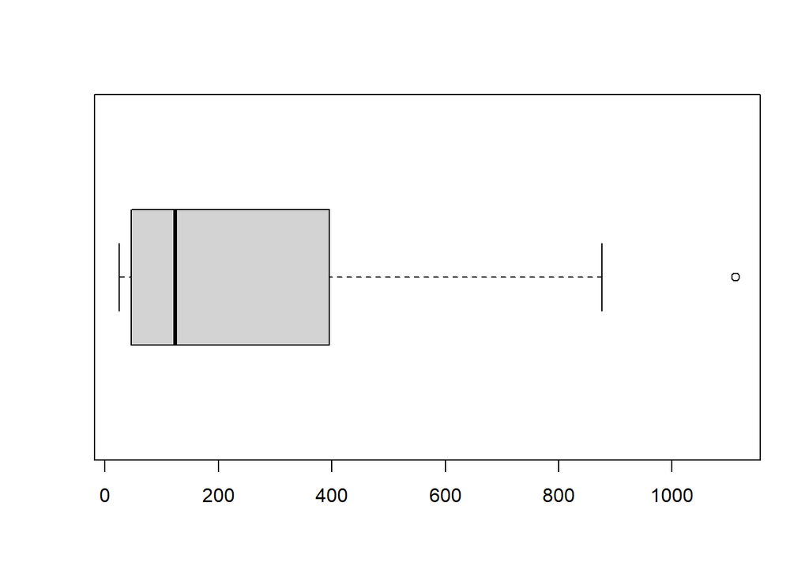

```r
> str(cancer)
List of 5
 $ stomach : num [1:13] 124 42 25 45 412 ...
 $ bronchus: num [1:17] 81 461 20 450 246 166 63 64 155 859 ...
 $ colon   : num [1:17] 248 377 189 1843 180 ...
 $ ovary   : num [1:6] 1234 89 201 356 2970 ...
 $ breast  : num [1:11] 1235 24 1581 1166 40 ...
> boxplot(cancer$stomach, horizontal = TRUE)
```

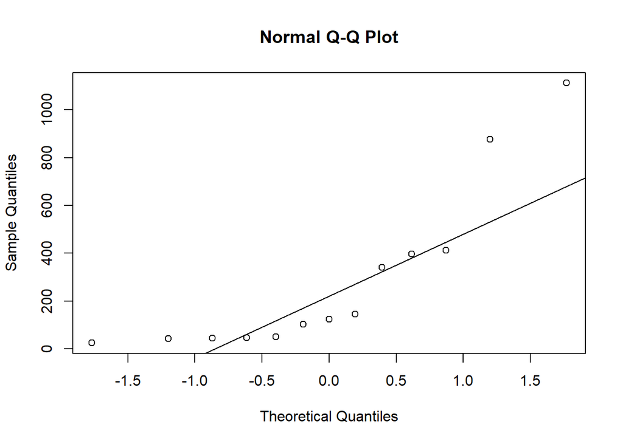

```r
> qqnorm(cancer$stomach)
> qqline(cancer$stomach)
```

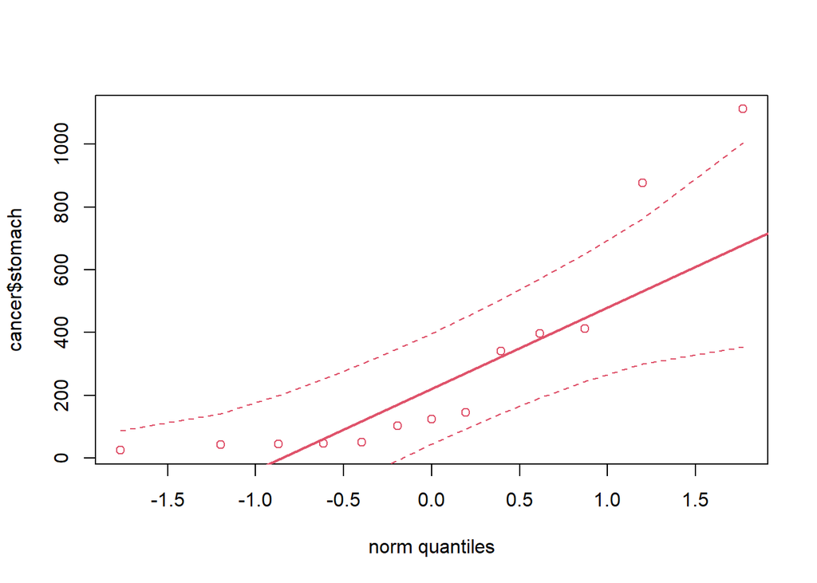

```r
> qqplot.das(cancer$stomach)
```

```r
> shapiro.test(cancer$stomach)

    Shapiro-Wilk normality test

data:  cancer$stomach
W = 0.75473, p-value = 0.002075
```

The $p-value = 0.002075 < 0.05 = \alpha$, so we reject $H_0$. The data is not normally distributed. We can’t use a t-test. We can make a hypothesis test for the median.

$$H_0: Me = 100\ days$$
$$H_A: Me \neq 100\ days$$

```r
> wilcox.test(cancer$stomach, mu = 100, alternative = "two.sided")

    Wilcoxon signed rank exact test

data:  cancer$stomach
V = 61, p-value = 0.3054
alternative hypothesis: true location is not equal to 100
```

The $p-value = 0.3054 > 0.05 = \alpha$, so we have no evidence to reject $H_0$. We can assume that people having stomach cancer in average survive $100$ days.

Let’s review the data for the brochus cancer. Test the hypothesis that the Median is $100$ days. Is the t-test appropriate here?

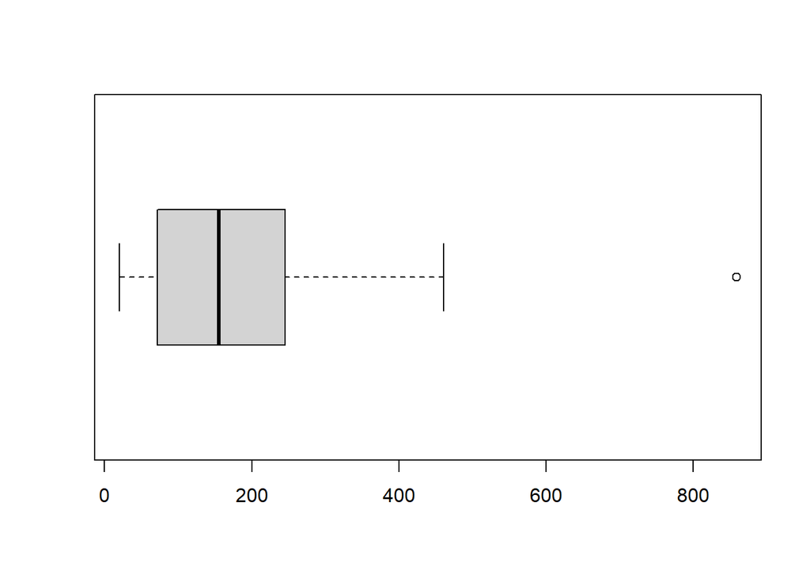

```r
> boxplot(cancer$bronchus, horizontal = TRUE)
```

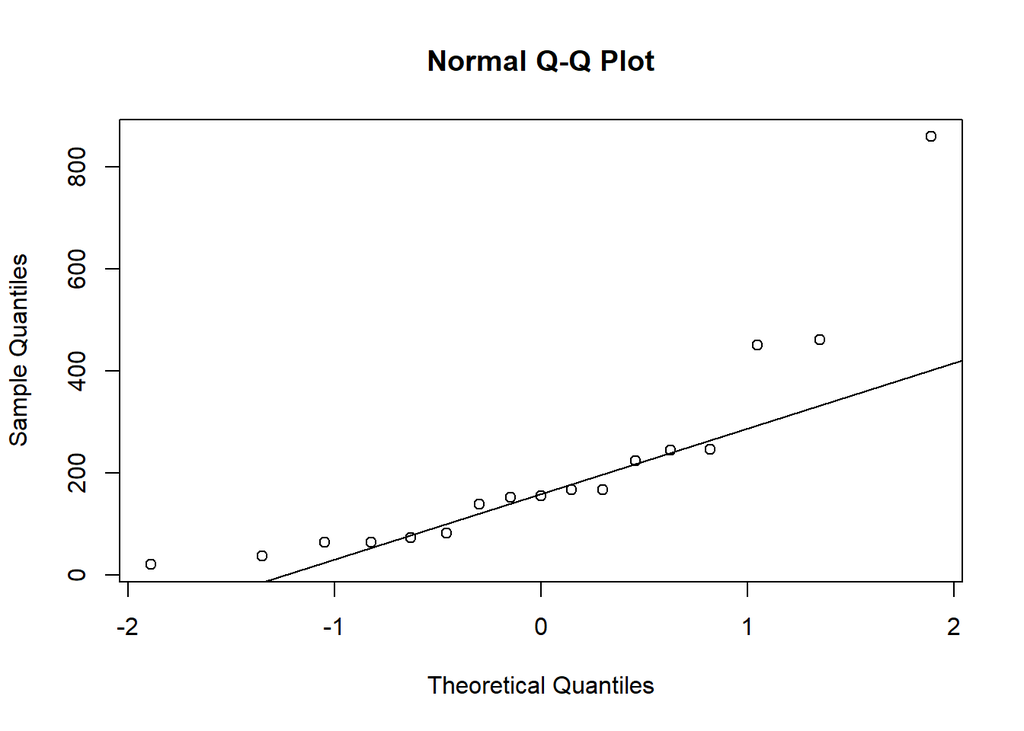

```r
> qqnorm(cancer$bronchus)
> qqline(cancer$bronchus)
```

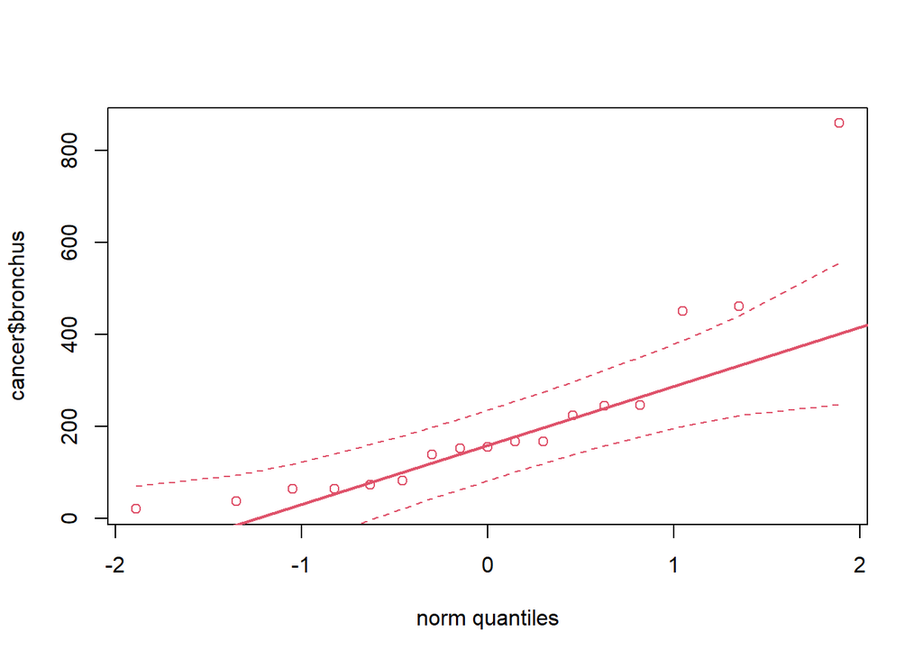

```r
> qqplot.das(cancer$bronchus)
```

```r
> shapiro.test(cancer$bronchus)

    Shapiro-Wilk normality test

data:  cancer$bronchus
W = 0.76596, p-value = 0.0007186
```

The $p-value = 0.0007186 < 0.05 = \alpha$, so we reject $H_0$. The data is not normally distributed. We can’t use a t-test. We can make a hypothesis test for the median.

$$H_0: Me = 100\ days$$
$$H_A: Me \neq 100\ days$$

```r
> wilcox.test(cancer$bronchus, mu = 100, alternative = "two.sided", conf.level = 0.95)
Warning in wilcox.test.default(cancer$bronchus, mu = 100, alternative =
"two.sided", : cannot compute exact p-value with ties

    Wilcoxon signed rank test with continuity correction

data:  cancer$bronchus
V = 124, p-value = 0.02607
alternative hypothesis: true location is not equal to 100
```

The $p-value = 0.02607 < 0.05 = \alpha$, so we reject $H_0$. The average time of survival from bronchus cancer is different than $100$ days.

Let’s review the data for the colon cancer. Test the hypothesis that the Median is $325$ days. Is the t-test appropriate here?

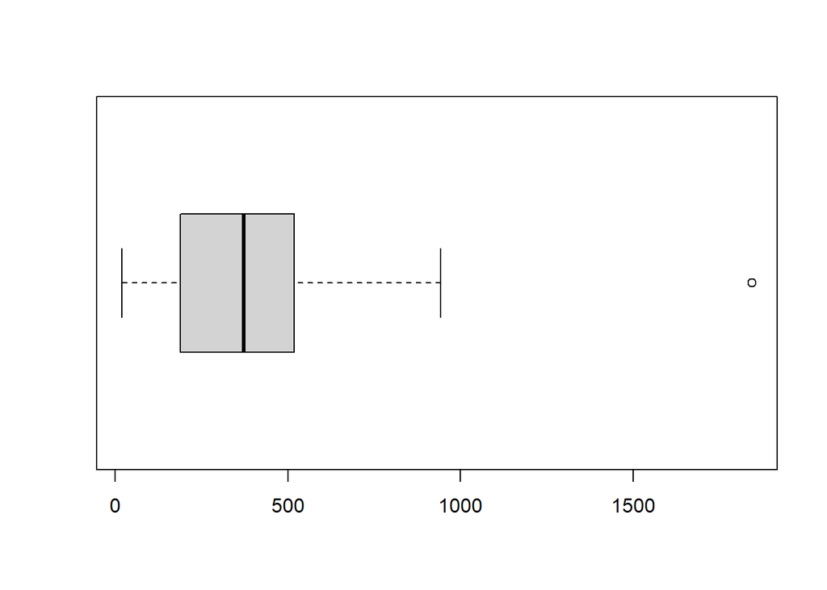

```r
> boxplot(cancer$colon, horizontal = TRUE)
```

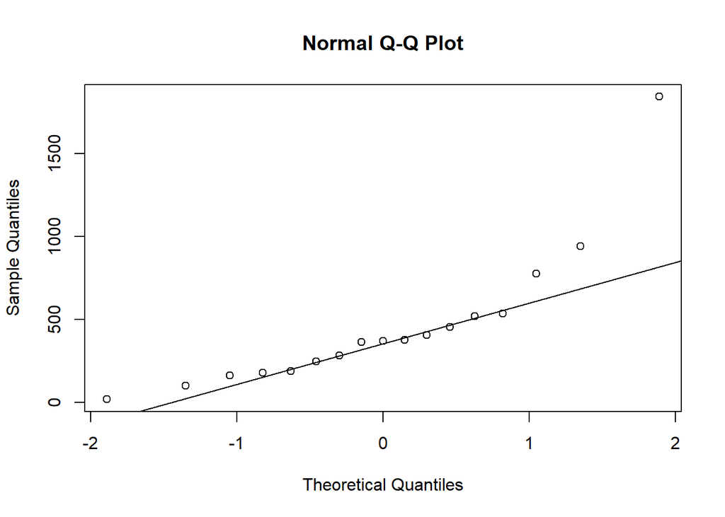

```r
> qqnorm(cancer$colon)
> qqline(cancer$colon)
```

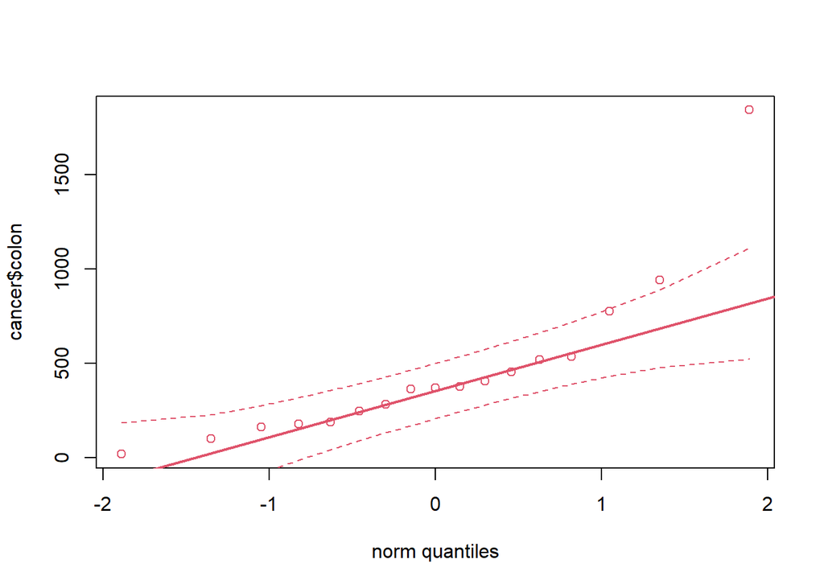

```r
> qqplot.das(cancer$colon)
```

```r
> shapiro.test(cancer$colon)

    Shapiro-Wilk normality test

data:  cancer$colon
W = 0.76056, p-value = 0.0006134
```

The $p-value = 0.0006134 < 0.05 = \alpha$, so we reject $H_0$. The data is not normally distributed. We can’t use a t-test. We can make a hypothesis test for the median.

$$H_0: Me = 325\ days$$
$$H_A: Me \neq 325\ days$$

```r
> wilcox.test(cancer$colon, mu = 325, alternative = "two.sided", conf.level = 0.95)

    Wilcoxon signed rank exact test

data:  cancer$colon
V = 92, p-value = 0.4874
alternative hypothesis: true location is not equal to 325
```

The $p-value = 0.4874 > 0.05 = \alpha$, so we have no evidence to reject $H_0$. The average time of survival from colon cancer is $325$ days.

Let’s review the data for the ovary cancer. Test the hypothesis that the Median is $325$ days. Is the t-test appropriate here?

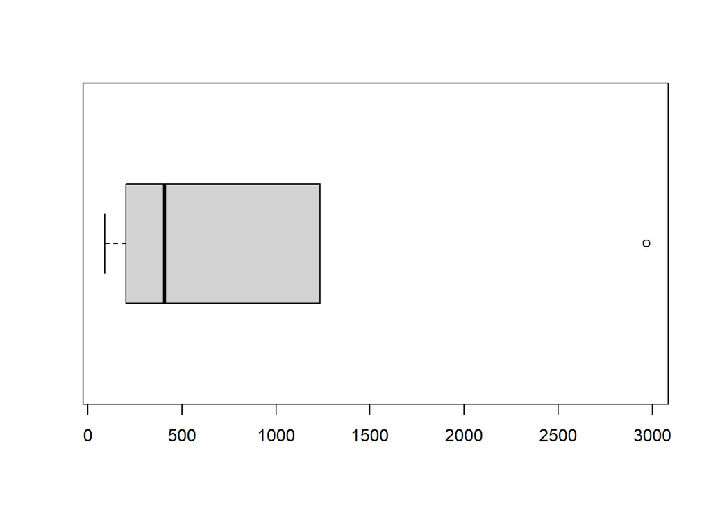

```r
> boxplot(cancer$ovary, horizontal = TRUE)
```

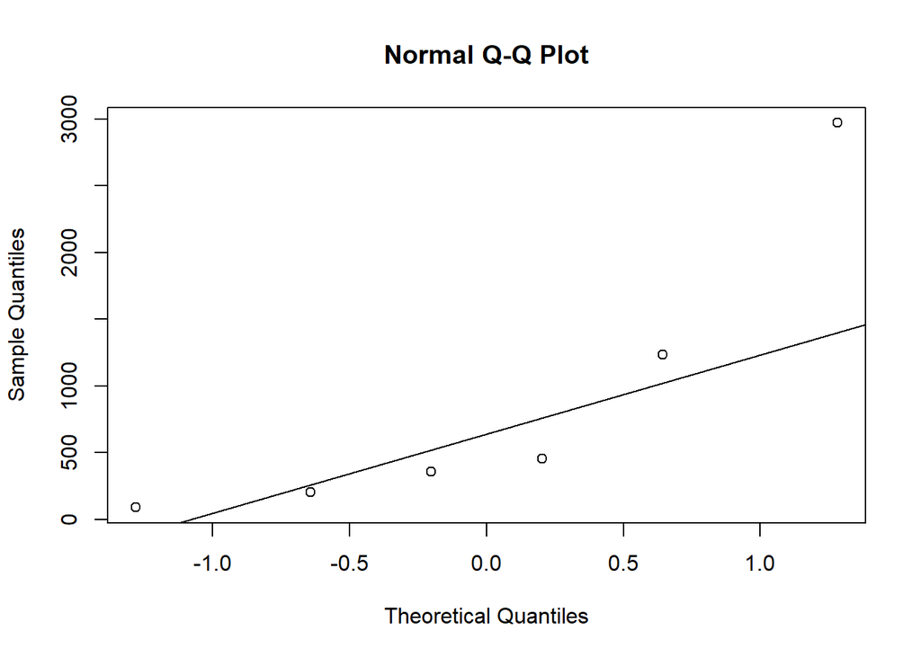

```r
> qqnorm(cancer$ovary)
> qqline(cancer$ovary)
```

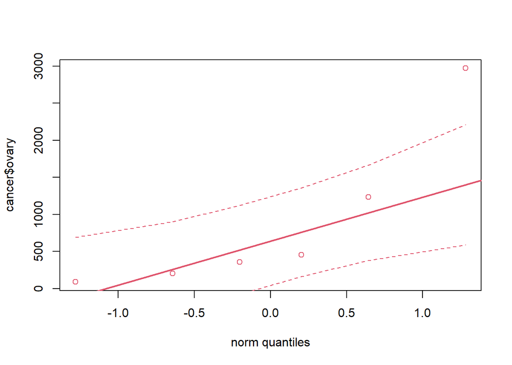

```r
> qqplot.das(cancer$ovary)
```

```r
> shapiro.test(cancer$ovary)

    Shapiro-Wilk normality test

data:  cancer$ovary
W = 0.76688, p-value = 0.029
```

The $p-value = 0.029 < 0.05 = \alpha$, so we reject $H_0$. The data is not normally distributed. We can’t use a t-test. We can make a hypothesis test for the median.

$$H_0: Me = 325\ days$$
$$H_A: Me \neq 325\ days$$

```r
> wilcox.test(cancer$ovary, mu = 325, alternative = "two.sided", conf.level = 0.95)

    Wilcoxon signed rank exact test

data:  cancer$ovary
V = 15, p-value = 0.4375
alternative hypothesis: true location is not equal to 325
```

The $p-value = 0.4375 > 0.05 = \alpha$, so we have no evidence to reject $H_0$. The average time of survival from ovary cancer is $325$ days.

Let’s review the data for the breast cancer. Test the hypothesis that the center is $1300$ days. Is the t-test appropriate here?

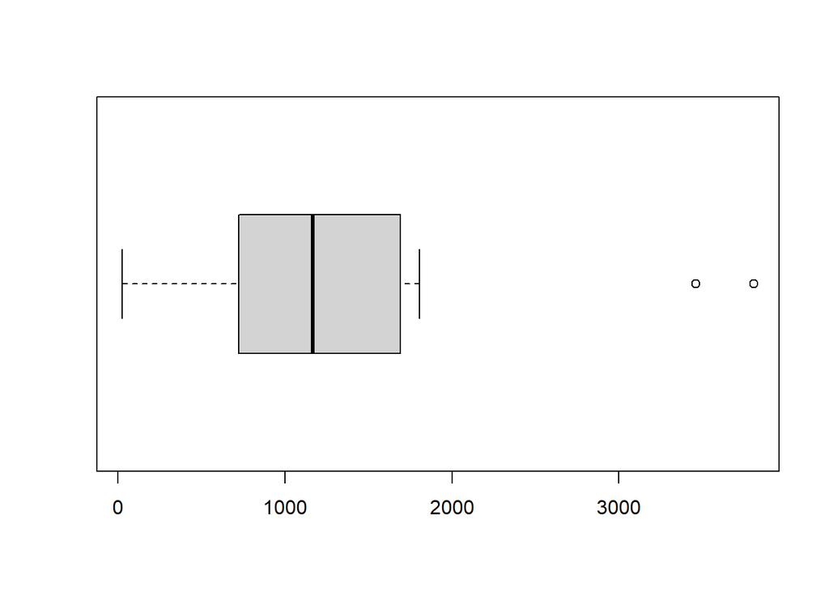

```r
> boxplot(cancer$breast, horizontal = TRUE)
```

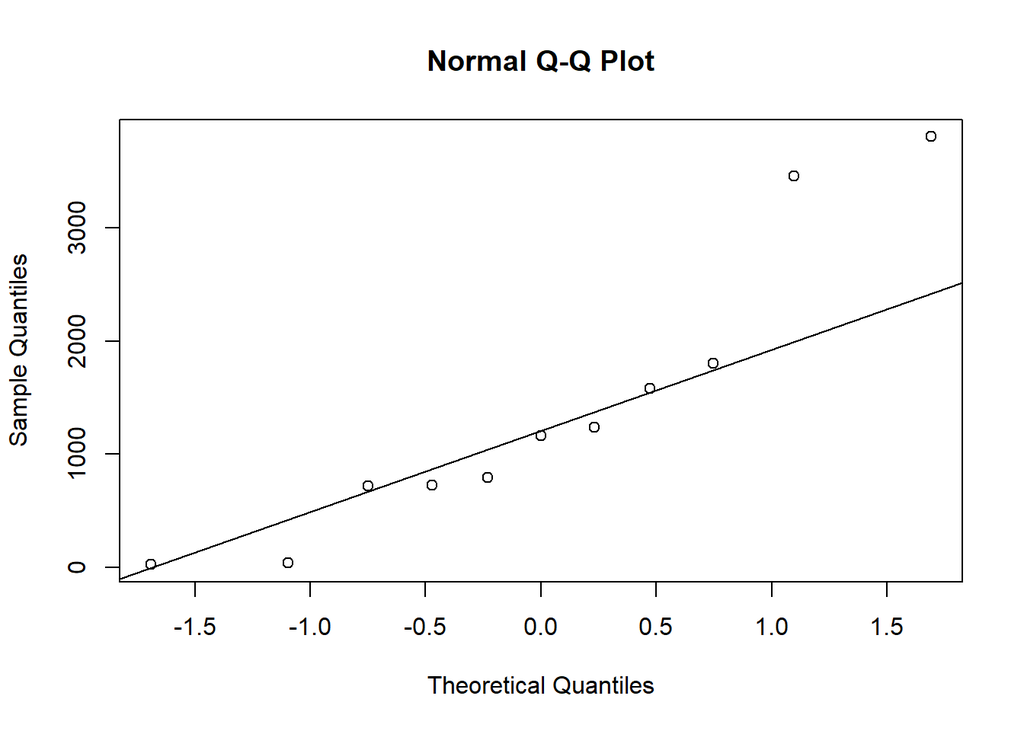

```r
> qqnorm(cancer$breast)
> qqline(cancer$breast)
```

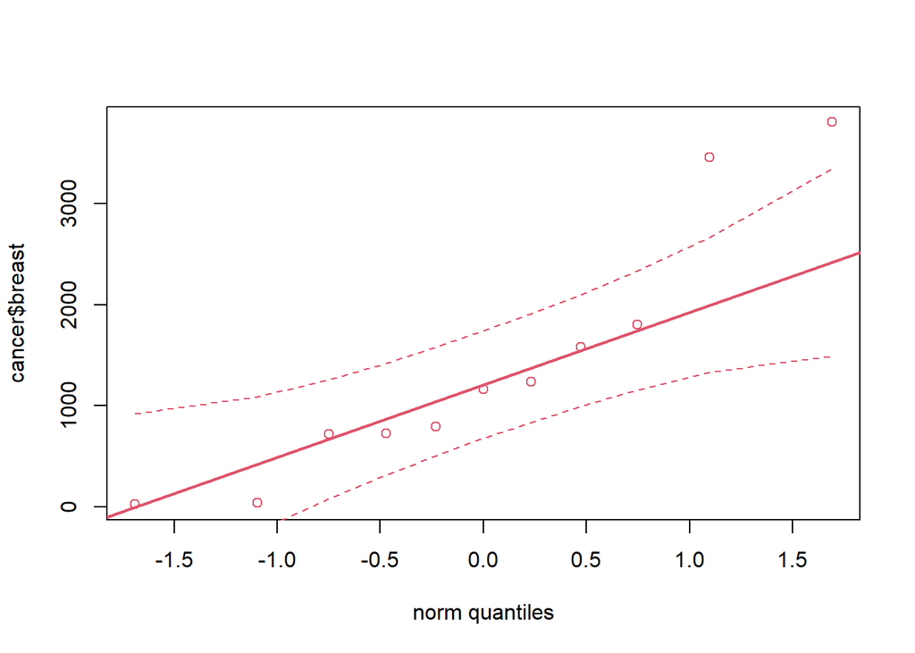

```r
> qqplot.das(cancer$breast)
```

```r
> shapiro.test(cancer$breast)

    Shapiro-Wilk normality test

data:  cancer$breast
W = 0.86857, p-value = 0.07431
```

The $p-value = 0.07431 > 0.05 = \alpha$, so we have no evidence to reject $H_0$. We an assume that the data is normally distributed. We don’t know the $\sigma$, so we can use a t-test.

$$H_0: \mu = 1300\ days$$
$$H_A: \mu \neq 1300\ days$$

```r
> t.test(cancer$breast, mu = 1300, alternative = "two.sided", conf.level = 0.95)

    One Sample t-test

data:  cancer$breast
t = 0.25674, df = 10, p-value = 0.8026
alternative hypothesis: true mean is not equal to 1300
95 percent confidence interval:
  563.5599 2228.2582
sample estimates:
mean of x
 1395.909
```

The $p-value = 0.8026 > 0.05 = \alpha$, so we have no evidence to reject $H_0$. The average time of survival from breast cancer is $1300$ days.